# Model Based Quality of Exercise Detection

Ryan Johnson

July 24, 2015

Devices like Fitbit, Nike FuelBand, and Jawbone Up have enabled the ability to collect a large amount of data about personal activity. These devices allow people to quantify how much of a particular activity they do. In this experiement, we use a dataset that includes data from accelerometers on a belt, forarm, arm and dumbell to try to quantify how well people perform an exercise activity. The dataset includes data from 6 participants who were instructed to perform an exercise correctly and incorrectly.

The dataset contains many variables. The “classe”" variable is the label for each sample and each class indicates how well a participant performed the exercise. Many of the variables are raw sensor values. The samples are taken at specific time intervals.

It is assumed that the training data includes discrete samples during a repetition of the exercise. At the end of the repetition, there are statistical calculations (mean, variance, etc…) of sampled data during the repetition. The samples with these computations are indicated with the “new_window” variable set to “yes”. Since I am not sure if these samples include the raw sensor data, I begin by removing these entries from the data. I also remove variables that have any “NA” entries and variables that are “NULL”.

Since the test set for the second part of this project is based on the raw sensor values, I attempt to build a model using the raw sensor values. As such, I remove the variables “X”, “user_name”, “raw_timestamp_part1”, “raw_timestamp_part_2”, “cvt_timestamp”, “new_window”, and “num_Window” from the predictors. Note: As a future improvement, it may be beneficial to create “features” using a window of time (sliding window at 1 second or 2 seconds, etc…).

The final list of predictors is as follows.

```r
colnames(data)
```

```
##  [1] "roll_belt"            "pitch_belt"           "yaw_belt"
##  [4] "total_accel_belt"     "gyros_belt_x"         "gyros_belt_y"
##  [7] "gyros_belt_z"         "accel_belt_x"         "accel_belt_y"
## [10] "accel_belt_z"         "magnet_belt_x"        "magnet_belt_y"
## [13] "magnet_belt_z"        "roll_arm"             "pitch_arm"
## [16] "yaw_arm"              "total_accel_arm"      "gyros_arm_x"
## [19] "gyros_arm_y"          "gyros_arm_z"          "accel_arm_x"
## [22] "accel_arm_y"          "accel_arm_z"          "magnet_arm_x"
## [25] "magnet_arm_y"         "magnet_arm_z"         "roll_dumbbell"
## [28] "pitch_dumbbell"       "yaw_dumbbell"         "total_accel_dumbbell"
## [31] "gyros_dumbbell_x"     "gyros_dumbbell_y"     "gyros_dumbbell_z"
## [34] "accel_dumbbell_x"     "accel_dumbbell_y"     "accel_dumbbell_z"
## [37] "magnet_dumbbell_x"    "magnet_dumbbell_y"    "magnet_dumbbell_z"
## [40] "roll_forearm"         "pitch_forearm"        "yaw_forearm"
## [43] "total_accel_forearm"  "gyros_forearm_x"      "gyros_forearm_y"
## [46] "gyros_forearm_z"      "accel_forearm_x"      "accel_forearm_y"
## [49] "accel_forearm_z"      "magnet_forearm_x"     "magnet_forearm_y"
## [52] "magnet_forearm_z"     "classe"
```

To get a feel for the correlation of the variables, consider the following a correlation matrix. Many of the variables are uncorrelated.

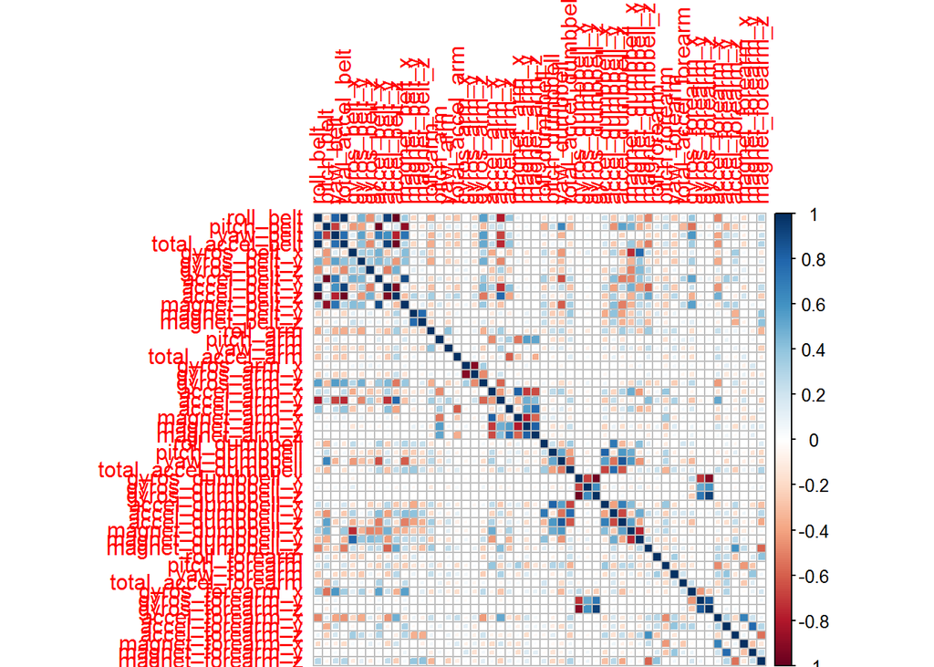

```r
# To get a feel for the variables, let's create a correlation matrix and plot
c <- cor(data[,1:52])
corrplot(c,method="square")
```

Using PCA, we could convert the variables that are correlated to a set of linearly uncorrelated variables. This will result in the largest amount of variability in the data possible.

Another approach is to use Random Forests (which uses sampling with replacement) to detect variable importance. Further, there have been studies showing that Random Forests are great models for activity detection where the raw sensors have a large amount of noise (See http://www.robertjross.org/wp-content/uploads/2014/04/ross-kelleher-uncertainty-in-AAL.pdf).

Leveraging this study, I choose not to pre-process the variables and use each variable in the list above to train a Random Forest model.

Because the dataset is large, I perform a 60%/20%/20% split - 60% for training, 20% for cross-validation, and 20% for test. The test set is separate from the test set of the second part of the project because I feel a larger test set will give a better indication of the expected out-of-sample error rate. The number of samples in each dataset is as follows:

```r
nrow(train)
```

```
## [1] 11532
```

```r
nrow(cv)
```

```
## [1] 3841
```

```r
nrow(test)
```

```
## [1] 3843
```

Random Forest create an unbiased estimate of the out-of-sample error during training because of the out-of-bag (oob) method employed. This helps Random Forests to not over-fit the data. To verify that the model is not over-fit, a learning curve is created using the training and cross-validation data sets. The learning curve is created by incrementing the maximum number of nodes allowed in each tree.

The following figure shows that as the maximum number of nodes is increased, the accuracy increases but the train accuracy and the cross-validation accuracy remain fairly consistent.

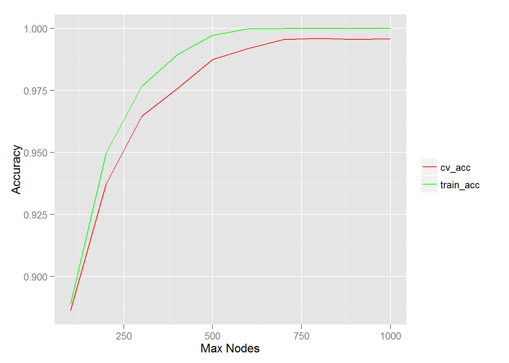

The best performing model will be a model that has no limitations on the maximum number of tree nodes. I train a model with no restriction on the number of tree nodes and allow for up to 500 trees. The “classe”" predictor is interpreted as a factor.

One of the main trade-offs with Random Forests is the training time. With a dataset this large, the training time can be long.

Because we used the cross-validation set for the learning curve, we must determine the final out-of-sample accuracy using the test set. The “randomForest” function can take the test set as an input and outputs the error rate. This matches the accuracy of the test set using the “predict” function.

```
##
## Call:
##  randomForest(x = train[, 1:52], y = factor(train$classe), xtest = test[,      1:52], ytest = factor(test$classe), ntree = 500, maxnodes = NULL,      importance = TRUE, keep.forest = TRUE)
##                Type of random forest: classification
##                      Number of trees: 500
## No. of variables tried at each split: 7
##
##         OOB estimate of  error rate: 0.72%
## Confusion matrix:
##      A    B    C    D    E class.error
## A 3279    2    0    0    2 0.001218398
## B   19 2203    9    0    0 0.012550426
## C    0   16 1994    2    0 0.008946322
## D    0    0   26 1861    2 0.014822657
## E    0    0    1    4 2112 0.002361833
##                 Test set error rate: 0.99%
## Confusion matrix:
##      A   B   C   D   E  class.error
## A 1093   1   0   0   0 0.0009140768
## B    3 739   2   0   0 0.0067204301
## C    0  13 655   2   0 0.0223880597
## D    0   0  15 613   1 0.0254372019
## E    0   0   0   1 705 0.0014164306
```

```r
print(train_acc * 100)
```

```
## [1] 100
```

```r
print(cv_acc*100)
```

```
## [1] 99.4793
```

```r
print(test_acc*100)
```

```
## [1] 99.01119
```

The importance of the variables is as follows:

```r
print(varImp(modFit))
```

```
##                             A        B        C        D        E
## roll_belt            35.40473 46.44845 44.67965 43.85847 42.65591
## pitch_belt           30.63939 48.37663 38.02560 31.11662 33.52951
## yaw_belt             48.14494 43.47958 43.76306 43.39432 34.78771
## total_accel_belt     12.66365 15.82765 12.86457 13.62795 15.41948
## gyros_belt_x         17.16172 16.66228 19.58182 13.68552 15.24591
## gyros_belt_y         11.01104 14.95227 15.84547 13.40578 16.86031
## gyros_belt_z         22.43117 27.23072 24.23391 20.42349 24.64725
## accel_belt_x         13.08010 17.35547 16.72450 13.49272 14.08916
## accel_belt_y         12.72150 16.46807 12.70851 16.02826 13.12025
## accel_belt_z         20.19711 23.90203 24.14956 23.49897 19.78417
## magnet_belt_x        19.30633 26.54831 25.14119 21.23445 24.25472
## magnet_belt_y        22.16904 27.19060 26.74483 26.37724 23.28311
## magnet_belt_z        23.08515 25.55597 24.33183 27.15472 22.47771
## roll_arm             22.93798 30.97237 28.35284 29.27061 22.74619
## pitch_arm            17.50048 22.70253 18.88429 19.65749 17.15588
## yaw_arm              22.13064 24.68720 22.67689 27.08375 20.46311
## total_accel_arm      10.09267 22.15797 17.86046 18.89955 17.68969
## gyros_arm_x          15.28542 27.88769 22.33242 22.44355 20.78371
## gyros_arm_y          20.32245 27.39876 22.29740 25.71024 23.36306
## gyros_arm_z          12.50153 15.95493 13.34025 15.09031 12.88261
## accel_arm_x          15.79272 17.97734 18.61835 20.72612 15.30397
## accel_arm_y          17.61462 20.84689 17.27540 19.52469 17.70122
## accel_arm_z          11.89670 18.91351 21.33108 20.26980 18.08041
## magnet_arm_x         18.10029 17.93145 19.89221 19.63861 16.31951
## magnet_arm_y         13.78704 17.79448 18.41692 21.33097 14.46701
## magnet_arm_z         18.67317 20.00696 21.29407 14.99995 14.03365
## roll_dumbbell        25.36273 27.73420 30.21325 29.81975 28.28120
## pitch_dumbbell       13.05666 21.94150 17.06944 14.12739 15.67289
## yaw_dumbbell         17.95145 25.08467 25.54544 23.65060 23.73721
## total_accel_dumbbell 21.40255 23.52540 21.38021 21.97288 23.70105
## gyros_dumbbell_x     15.73966 23.48031 20.41926 18.60117 18.45691
## gyros_dumbbell_y     24.95013 22.81155 26.39503 21.25133 19.12701
## gyros_dumbbell_z     16.46922 21.89910 16.98968 16.57513 15.19260
## accel_dumbbell_x     16.68286 23.39013 20.18336 18.71558 19.69875
## accel_dumbbell_y     26.56978 29.50445 31.36639 27.93602 27.97871
## accel_dumbbell_z     20.33064 26.86632 24.25721 24.72713 28.39697
## magnet_dumbbell_x    25.04216 25.94091 30.28857 27.01458 22.88357
## magnet_dumbbell_y    32.34086 32.53662 41.74033 32.76192 29.47162
## magnet_dumbbell_z    41.36625 36.08229 44.68833 36.95786 36.03472
## roll_forearm         28.70491 24.89253 30.67612 22.97470 23.55064
## pitch_forearm        31.33033 32.61930 36.63584 34.05751 33.11873
## yaw_forearm          18.76263 20.05536 21.20876 18.80910 21.50593
## total_accel_forearm  16.83113 18.05346 20.99886 17.58154 16.72481
## gyros_forearm_x      12.21104 17.54721 16.50292 16.94247 15.77514
## gyros_forearm_y      14.27032 27.39349 22.20681 20.92378 19.71529
## gyros_forearm_z      16.37751 23.12522 19.09598 16.40893 14.36187
## accel_forearm_x      20.04701 25.47578 25.31701 29.09839 23.51953
## accel_forearm_y      19.36284 21.70886 21.37869 19.01704 19.67020
## accel_forearm_z      17.65402 24.31246 25.90416 23.35186 23.73372
## magnet_forearm_x     14.59285 18.95322 19.24110 16.26431 17.68041
## magnet_forearm_y     20.35372 22.13341 22.71884 21.12365 20.11055
## magnet_forearm_z     23.11189 28.13903 25.62443 26.83249 23.78125
```

Since the train and test accuracies are similar, I conclude that the model is not over fit. The test accuracy is very high. I would expect prediction of out-of-sample data to be about 99% accurate. The accuracy is high enough that there is no reason to try other models for improvement.

The data for this project come from this source: http://groupware.les.inf.puc-rio.br/har.